# Working with Databases - Part I

Dr. Hua Zhou @ UCLA

Feb 18, 2020

## Acknowledgement

Much material in this lecture is adpated from http://www2.stat.duke.edu/~cr173/Sta523_Fa17/sql.html and http://www2.stat.duke.edu/~cr173/Sta523_Fa17/bigish_data.html.

# Why databases?

## Size of data

- Small data: those can fit into computer memory.
- Bigish data: those can fit into disk(s) of a single machine.
- Big data: those cannot fit into disk(s) of a single machine.

## Computer architecture

> Key to high performance is effective use of memory hierarchy. True on all architectures.

[figure not shown]

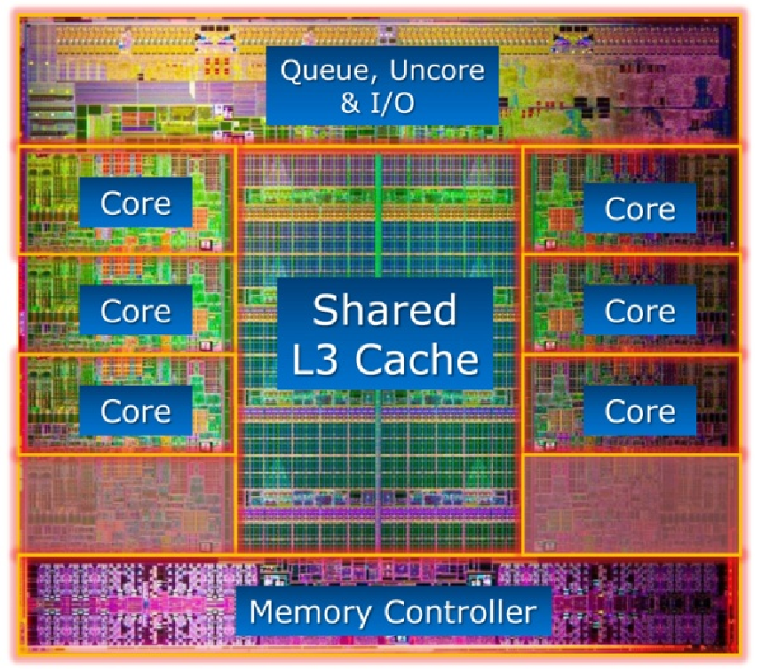

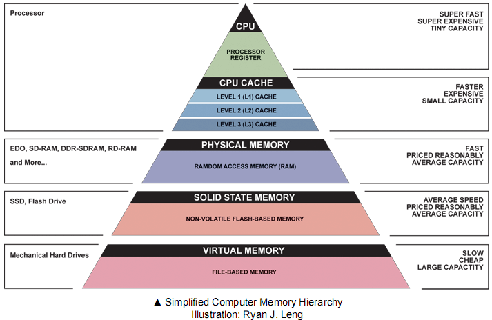

## Numbers everyone should know

| Operation | Time |
| --- | --- |
| L1 cache reference | 0.5 ns |
| L2 cache reference | 7 ns |
| Main memory reference | 100 ns |
| Read 1 MB sequentially from memory | 250,000 ns |
| Read 1 MB sequentially from SSD | 1,000,000 ns |
| Read 1 MB sequentially from disk | 20,000,000 ns |

Source: https://gist.github.com/jboner/2841832

## Implications for bigish data

Suppose we have a 10 GB flat data file and that we want to select certain rows based on a given criteria. This requires a sequential read across the entire data set.

If we can store the file in memory:  
10 GB × (250 μs/1 MB) = 2.5 seconds

If we have to access the file from SSD (~1GB/sec):  
10 GB × (1 ms/1 MB) = 10 seconds

If we have to access the file from disk:  
10 GB × (20 ms/1 MB) = 200 seconds

This is just for reading data, if we make any modifications (writing) things are much worse.

## Blocks

Cost: Disk << Memory

Speed: Disk <<< Memory

So usually possible to grow our disk storage to accommodate our data. However, memory is usually the limiting resource, and what if we can’t fit everything into memory?

Create blocks - group rows based on similar attributes and read in multiple rows at a time. Optimal size will depend on the task and the properties of the disk.

## Linear vs binary Search

Even with blocks, any kind of subsetting of rows requires a linear search, which requires $O(N)$ accesses where $N$ is the number of blocks.

We can do much better if we are careful about how we structure our data, specifically sorting some or all of the columns.

- Sorting is expensive, $O(N \log N)$, but it only needs to be done once.
- After sorting, we can use a binary search for any subsetting tasks $O(\log N)$.
- These sorted columns are known as *indexes*.
- Indexes require additional storage, but usually small enough to be kept in memory while blocks stay on disk.

# Databases

## SQL

**S**tructured **Q**uery **L**anguage is a special purpose language for interacting with (querying and modifying) these indexed tabular data structures.

- ANSI Standard but with some dialect divergence.
- SQL functionalities map very closely (but not exactly) with the data manipulation verbs present in dplyr.
- We will see this mapping in more detail in a bit.

## Access databases from R

- dplyr package supports a variety of databases.
  - Open source databases: SQLite, MySQL, PostgreSQL, BigQuery.
  - Commercial databases: Oracle, Microsoft SQL Server.
  - See [link](https://db.rstudio.com/databases) for a complete list.
- DBI package provides a common interface for connecting to databases.
- dbplyr package is the backend that translates dplyr verbs to database SQL queries.
- To install database drivers, follow instructions at https://db.rstudio.com/best-practices/drivers/.

# A sample session using SQLite

## Create a SQLite database

Create a SQLite database `employee.sqlite` (or *in memory*) for learning purpose.

```r
library("DBI")
library("RSQLite")
con = dbConnect(RSQLite::SQLite(), "employee.sqlite")
#con = dbConnect(RSQLite::SQLite(), ":memory:")
str(con)
```

```
## Formal class 'SQLiteConnection' [package "RSQLite"] with 7 slots
##   ..@ ptr                :<externalptr>
##   ..@ dbname             : chr "employee.sqlite"
##   ..@ loadable.extensions: logi TRUE
##   ..@ flags              : int 70
##   ..@ vfs                : chr ""
##   ..@ ref                :<environment: 0x7fc18a2d5c80>
##   ..@ bigint             : chr "integer64"
```

## Add a table into database

First table:

```r
library("tidyverse")
(employees <- tibble(name   = c("Alice", "Bob", "Carol", "Dave", "Eve", "Frank"),
                     email  = c("alice@company.com", "bob@company.com",
                                "carol@company.com", "dave@company.com",
                                "eve@company.com",   "frank@comany.com"),
                     salary = c(52000, 40000, 30000, 33000, 44000, 37000),
                     dept   = c("Accounting", "Accounting", "Sales",
                                "Accounting", "Sales", "Sales")))
```

```
## # A tibble: 6 x 4
##   name  email             salary dept
##   <chr> <chr>              <dbl> <chr>
## 1 Alice alice@company.com  52000 Accounting
## 2 Bob   bob@company.com    40000 Accounting
## 3 Carol carol@company.com  30000 Sales
## 4 Dave  dave@company.com   33000 Accounting
## 5 Eve   eve@company.com    44000 Sales
## 6 Frank frank@comany.com   37000 Sales
```

Second table:

```r
(phone <- tibble(name  = c("Bob", "Carol", "Eve", "Frank"),
                 phone = c("919 555-1111", "919 555-2222", "919 555-3333", "919 555-4444")))
```

```
## # A tibble: 4 x 2
##   name  phone
##   <chr> <chr>
## 1 Bob   919 555-1111
## 2 Carol 919 555-2222
## 3 Eve   919 555-3333
## 4 Frank 919 555-4444
```

Write tables to the database:

```r
dbWriteTable(con, "employees", employees, overwrite = TRUE)
dbWriteTable(con, "phone", phone, overwrite = TRUE)
dbListTables(con)
```

```
## [1] "employees" "phone"
```

## Add another table

```r
dbWriteTable(con, "employs", employees)
dbListTables(con)
```

```
## [1] "employees" "employs"   "phone"
```

## Remove a table from database

```r
dbRemoveTable(con, "employs")
dbListTables(con)
```

```
## [1] "employees" "phone"
```

## Querying tables

```r
# select all columns from table employees
res <- dbSendQuery(con, "SELECT * FROM employees")
# execute the query
dbFetch(res)
```

```
##    name             email salary       dept
## 1 Alice alice@company.com  52000 Accounting
## 2   Bob   bob@company.com  40000 Accounting
## 3 Carol carol@company.com  30000      Sales
## 4  Dave  dave@company.com  33000 Accounting
## 5   Eve   eve@company.com  44000      Sales
## 6 Frank  frank@comany.com  37000      Sales
```

```r
dbClearResult(res)
```

## Closing the connection

```r
dbDisconnect(con)
```

# SQL Queries

Following we demonstrate some common SQL commands, although all task can be achieved by using dplyr as well.

## Connecting

```r
con <- dbConnect(RSQLite::SQLite(), dbname = "employee.sqlite")
dbListTables(con)
```

```
## [1] "employees" "phone"
```

```r
knitr::opts_chunk$set(connection = "con")
```

## SELECT statements

```sql
SELECT * FROM employees;
```

6 records

| name | email | salary | dept |
| --- | --- | --- | --- |
| Alice | alice@company.com | 52000 | Accounting |
| Bob | bob@company.com | 40000 | Accounting |
| Carol | carol@company.com | 30000 | Sales |
| Dave | dave@company.com | 33000 | Accounting |
| Eve | eve@company.com | 44000 | Sales |
| Frank | frank@comany.com | 37000 | Sales |

```sql
SELECT * FROM phone;
```

4 records

| name | phone |
| --- | --- |
| Bob | 919 555-1111 |
| Carol | 919 555-2222 |
| Eve | 919 555-3333 |
| Frank | 919 555-4444 |

## Select using SELECT

```sql
SELECT name AS first_name, salary FROM employees;
```

6 records

| first_name | salary |
| --- | --- |
| Alice | 52000 |
| Bob | 40000 |
| Carol | 30000 |
| Dave | 33000 |
| Eve | 44000 |
| Frank | 37000 |

## Arrange using ORDER BY

```sql
SELECT name AS first_name, salary FROM employees ORDER BY salary;
```

6 records

| first_name | salary |
| --- | --- |
| Carol | 30000 |
| Dave | 33000 |
| Frank | 37000 |
| Bob | 40000 |
| Eve | 44000 |
| Alice | 52000 |

Descending order:

```sql
SELECT name AS first_name, salary FROM employees ORDER BY salary DESC;
```

6 records

| first_name | salary |
| --- | --- |
| Alice | 52000 |
| Eve | 44000 |
| Bob | 40000 |
| Frank | 37000 |
| Dave | 33000 |
| Carol | 30000 |

## Filter via WHERE

```sql
SELECT * FROM employees WHERE salary < 40000
```

3 records

| name | email | salary | dept |
| --- | --- | --- | --- |
| Carol | carol@company.com | 30000 | Sales |
| Dave | dave@company.com | 33000 | Accounting |
| Frank | frank@comany.com | 37000 | Sales |

## Group_by via GROUP BY

```sql
SELECT * FROM employees GROUP BY dept;
```

2 records

[output not shown]

## Head via LIMIT

```sql
SELECT * FROM employees LIMIT 3;
```

3 records

| name | email | salary | dept |
| --- | --- | --- | --- |
| Alice | alice@company.com | 52000 | Accounting |
| Bob | bob@company.com | 40000 | Accounting |
| Carol | carol@company.com | 30000 | Sales |

```sql
SELECT * FROM employees ORDER BY name DESC LIMIT 3;
```

3 records

| name | email | salary | dept |
| --- | --- | --- | --- |
| Frank | frank@comany.com | 37000 | Sales |
| Eve | eve@company.com | 44000 | Sales |
| Dave | dave@company.com | 33000 | Accounting |

## Join two tables (default)

By default SQLite uses a `CROSS JOIN` which is not terribly useful

```sql
SELECT * FROM employees JOIN phone;
```

Displaying records 1 - 10

| name | email | salary | dept | name | phone |
| --- | --- | --- | --- | --- | --- |
| Alice | alice@company.com | 52000 | Accounting | Bob | 919 555-1111 |
| Alice | alice@company.com | 52000 | Accounting | Carol | 919 555-2222 |
| Alice | alice@company.com | 52000 | Accounting | Eve | 919 555-3333 |
| Alice | alice@company.com | 52000 | Accounting | Frank | 919 555-4444 |
| Bob | bob@company.com | 40000 | Accounting | Bob | 919 555-1111 |
| Bob | bob@company.com | 40000 | Accounting | Carol | 919 555-2222 |
| Bob | bob@company.com | 40000 | Accounting | Eve | 919 555-3333 |
| Bob | bob@company.com | 40000 | Accounting | Frank | 919 555-4444 |
| Carol | carol@company.com | 30000 | Sales | Bob | 919 555-1111 |
| Carol | carol@company.com | 30000 | Sales | Carol | 919 555-2222 |

## Inner join by NATURAL

```sql
SELECT * FROM employees NATURAL JOIN phone;
```

4 records

| name | email | salary | dept | phone |
| --- | --- | --- | --- | --- |
| Bob | bob@company.com | 40000 | Accounting | 919 555-1111 |
| Carol | carol@company.com | 30000 | Sales | 919 555-2222 |
| Eve | eve@company.com | 44000 | Sales | 919 555-3333 |
| Frank | frank@comany.com | 37000 | Sales | 919 555-4444 |

## Inner join - explicit

```sql
SELECT * FROM employees JOIN phone ON employees.name = phone.name;
```

4 records

| name | email | salary | dept | name | phone |
| --- | --- | --- | --- | --- | --- |
| Bob | bob@company.com | 40000 | Accounting | Bob | 919 555-1111 |
| Carol | carol@company.com | 30000 | Sales | Carol | 919 555-2222 |
| Eve | eve@company.com | 44000 | Sales | Eve | 919 555-3333 |
| Frank | frank@comany.com | 37000 | Sales | Frank | 919 555-4444 |

## Left join - natural

```sql
SELECT * FROM employees NATURAL LEFT JOIN phone;
```

6 records

| name | email | salary | dept | phone |
| --- | --- | --- | --- | --- |
| Alice | alice@company.com | 52000 | Accounting | NA |
| Bob | bob@company.com | 40000 | Accounting | 919 555-1111 |
| Carol | carol@company.com | 30000 | Sales | 919 555-2222 |
| Dave | dave@company.com | 33000 | Accounting | NA |
| Eve | eve@company.com | 44000 | Sales | 919 555-3333 |
| Frank | frank@comany.com | 37000 | Sales | 919 555-4444 |

## Left join - explicit

```sql
SELECT * FROM employees LEFT JOIN phone ON employees.name = phone.name;
```

6 records

| name | email | salary | dept | name | phone |
| --- | --- | --- | --- | --- | --- |
| Alice | alice@company.com | 52000 | Accounting | NA | NA |
| Bob | bob@company.com | 40000 | Accounting | Bob | 919 555-1111 |
| Carol | carol@company.com | 30000 | Sales | Carol | 919 555-2222 |
| Dave | dave@company.com | 33000 | Accounting | NA | NA |
| Eve | eve@company.com | 44000 | Sales | Eve | 919 555-3333 |
| Frank | frank@comany.com | 37000 | Sales | Frank | 919 555-4444 |

## Other joins

SQLite does not support directly an `OUTER JOIN` or a `RIGHT JOIN`.

## Creating indices

```sql
CREATE INDEX index_name ON employees (name);
```

```sql
CREATE INDEX index_name_email ON employees (name, email);
```

```bash
sqlite3 employee.sqlite .indices
```

```
## index_name        index_name_email
```

## Close connection

```r
dbDisconnect(con)
```